# IDS investigation worksheet

by Error 404 Phenomonal Formulators: Hannah Birkinshaw, Isabel Leale, Suyan Bai & Zhou Jinning

2026-11-27

**Note:** You can use this file as you ‘working document’ where you can try out various investigation ideas and keep notes about your findings. How you use and structure this file is up to you. It is recommended that you keep notes about what you are investigating and what you find as this will make the process of creating your presentation and report easier. Please note that you *do not* need to submit this file as part of your group project.

```r
library(tidyverse)
library(ggplot2)
library(tidymodels)
library(knitr)
```

```r
bike_data <- read.csv("SeoulBikeData.csv")
```

```r
names(bike_data)
```

```
##  [1] "Date"                      "Rented.Bike.Count"
##  [3] "Hour"                      "Temperature.蚓."
##  [5] "Humidity..."               "Wind.speed..m.s."
##  [7] "Visibility..10m."          "Dew.point.temperature.蚓."
##  [9] "Solar.Radiation..MJ.m2."   "Rainfall.mm."
## [11] "Snowfall..cm."             "Seasons"
## [13] "Holiday"                   "Functioning.Day"
```

**Introducing the Dataset**

**Basic Summary Statistics**

```r
bike_data%>%
  summarise(
          min_rent = min(Rented.Bike.Count),
          avg_rent = mean(Rented.Bike.Count, na.rm= TRUE),
          med_rent = median(Rented.Bike.Count),
          max_rent = max(Rented.Bike.Count),
          sd_rent = sd(Rented.Bike.Count),
          iqr_rent = IQR(Rented.Bike.Count),
          quantile(probs = 0.25, Rented.Bike.Count),
          quantile(probs = 0.5, Rented.Bike.Count),
          quantile(probs = 0.75, Rented.Bike.Count))
```

```
##   min_rent avg_rent med_rent max_rent  sd_rent iqr_rent
## 1        0 704.6021    504.5     3556 644.9975   874.25
##   quantile(probs = 0.25, Rented.Bike.Count)
## 1                                       191
##   quantile(probs = 0.5, Rented.Bike.Count)
## 1                                    504.5
##   quantile(probs = 0.75, Rented.Bike.Count)
## 1                                   1065.25
```

HISTOGRAM OF BIKE RENTALS

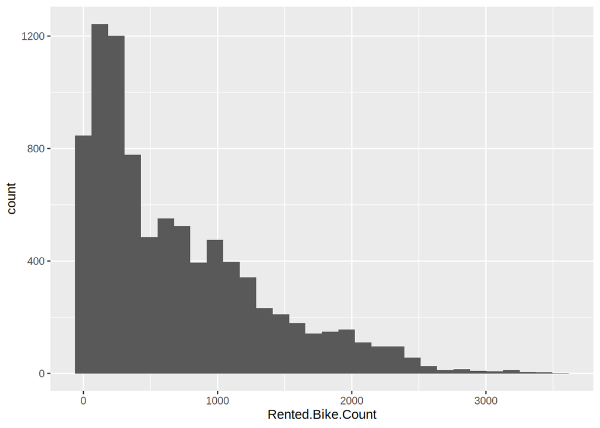

```r
ggplot(data = bike_data,
       mapping = aes(x = Rented.Bike.Count)) +
  geom_histogram()
```

Positively Skewed 8760 entries 14 variables mean = 704.602 median = 504.5 IQR = 874.25 What does this mean??

**Exploring Temporal Variables**

FUNCTIONING DAYS

```r
bike_data %>%
  count(Functioning.Day)
```

```
##   Functioning.Day    n
## 1              No  295
## 2             Yes 8465
```

```r
bike_data %>%
  group_by(Functioning.Day)%>%
  summarise(mean_func = mean(Rented.Bike.Count, na.rm = TRUE))
```

```
## # A tibble: 2 × 2
##   Functioning.Day mean_func
##   <chr>               <dbl>
## 1 No                     0
## 2 Yes                  729.
```

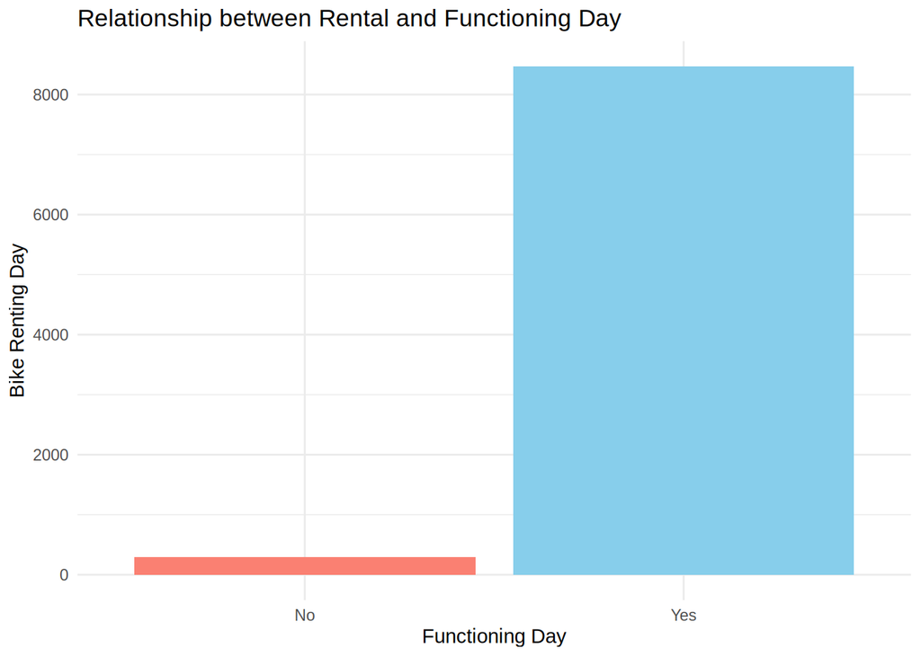

```r
bike_data %>%
  drop_na(Rented.Bike.Count, Functioning.Day) %>%
  ggplot(aes(x = Functioning.Day, fill = Functioning.Day)) +
  scale_fill_manual(values = c("No" = "salmon",
                               "Yes" = "skyblue")) +
  geom_bar() +
  labs(x = "Functioning Day",
       y = "Bike Renting Day",
       title = "Relationship between Rental and Functioning Day") +
  theme_minimal() +
  theme(legend.position = "none")
```

From the data it can be determined that there were 295 instances of non functioning hours of the Seoul Bike Rental Service between 2017 and 2018, suggesting 12.3 days of the year the bikes were out of commission. This is approximately 3.36% of the year where bikes were unavailable to be rented.

This causes a significant drop in mean bike rentals inclusive and exclusive of the non-functioning days, where bike rental is 0. On functioning days only, the mean is 729.157 rentals per hour, however throughout the whole year the rental rate is 704.602 rentals per hour.

**Exploring Further** Testing for significance

TESTING

H0: μ = 729.157 H1: μ < 729.157

x̄ =704.602

HOLIDAYS

```r
bike_data%>%
  group_by(Holiday)%>%
  summarise(
          min_rent = min(Rented.Bike.Count),
          avg_rent = mean(Rented.Bike.Count, na.rm= TRUE),
          med_rent = median(Rented.Bike.Count),
          max_rent = max(Rented.Bike.Count),
          sd_rent = sd(Rented.Bike.Count),
          quantile(probs = 0.25, Rented.Bike.Count),
          quantile(probs = 0.5, Rented.Bike.Count),
          quantile(probs = 0.75, Rented.Bike.Count))
```

```
## # A tibble: 2 × 9
##   Holiday    min_rent avg_rent med_rent max_rent sd_rent quantile(probs = 0.25…¹
##   <chr>         <int>    <dbl>    <dbl>    <int>   <dbl>                   <dbl>
## 1 Holiday           0     500.     240      2400    571.                    106.
## 2 No Holiday        0     715.     524.     3556    647.                    200
## # ℹ abbreviated name: ¹`quantile(probs = 0.25, Rented.Bike.Count)`
## # ℹ 2 more variables: `quantile(probs = 0.5, Rented.Bike.Count)` <dbl>,
## #   `quantile(probs = 0.75, Rented.Bike.Count)` <dbl>
```

From the data we can see on average that the number of bike rentals decrease during holidays from a mean of 715.2280 to 499.7569, this is significant as it suggests that the majority of rentals perhaps are related to comuttors travel to and from work/ school, further suggesting that rentals mainly occur among the working-aged demographic.

This perhaps suggest the Seoul government should campaign to increase bike rentals on holiday days more.

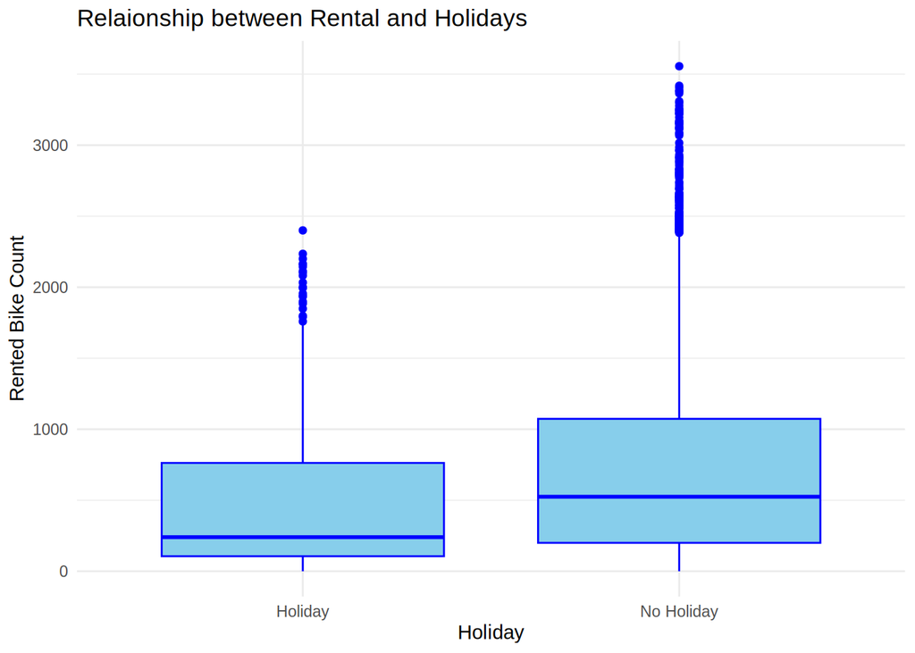

```r
bike_data %>%
  drop_na(Rented.Bike.Count,Holiday) %>%
  ggplot(aes(x = Holiday, y = Rented.Bike.Count)) +
  geom_boxplot(color = "blue",
               fill = "skyblue") +
  labs(x = "Holiday",
       y = "Rented Bike Count",
       title = "Relaionship between Rental and Holidays") +
  theme_minimal() +
  theme(legend.position = "bottom")
```

However from the graph, it also becomes apparent that there are many more outliers on non-holiday says. This could suggest bike rentals vary perhaps more greatly on these days as suggested by the greater standard deviation of 646.8791 to 570.7728.

Peraps in future it may be prudent to explore the clientel of bike renters in Seoul or even the concentration of rentals around Soeul to ensure bikes are available in the most relavant locations.

**Exploring Further** (perhaps dp a liogistic regression model??? rain or temp)

SEASONS

```r
bike_data%>%
  group_by(Seasons)%>%
  summarise(
          min_rent = min(Rented.Bike.Count),
          avg_rent = mean(Rented.Bike.Count, na.rm= TRUE),
          med_rent = median(Rented.Bike.Count),
          max_rent = max(Rented.Bike.Count),
          sd_rent = sd(Rented.Bike.Count),
          quantile(probs = 0.25, Rented.Bike.Count),
          quantile(probs = 0.5, Rented.Bike.Count),
          quantile(probs = 0.75, Rented.Bike.Count),
          IQR(Rented.Bike.Count, na.rm = FALSE))
```

```
## # A tibble: 4 × 10
##   Seasons min_rent avg_rent med_rent max_rent sd_rent quantile(probs = 0.25, R…¹
##   <chr>      <int>    <dbl>    <dbl>    <int>   <dbl>                      <dbl>
## 1 Autumn         0     820.     764.     3298    651.                       242.
## 2 Spring         0     730.     583      3251    622.                       206
## 3 Summer         9    1034.     906.     3556    690.                       527.
## 4 Winter         3     226.     203       937    150.                       110
## # ℹ abbreviated name: ¹`quantile(probs = 0.25, Rented.Bike.Count)`
## # ℹ 3 more variables: `quantile(probs = 0.5, Rented.Bike.Count)` <dbl>,
## #   `quantile(probs = 0.75, Rented.Bike.Count)` <dbl>,
## #   `IQR(Rented.Bike.Count, na.rm = FALSE)` <dbl>
```

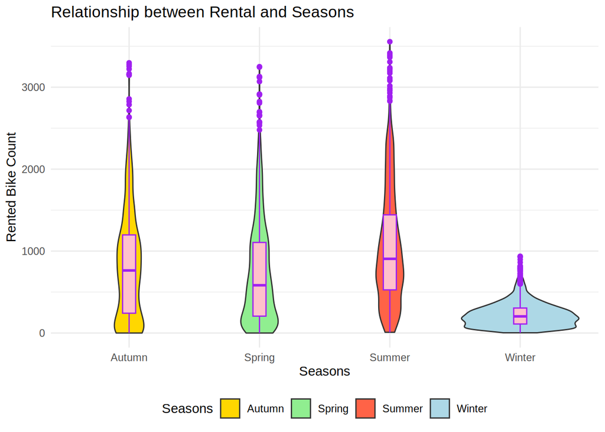

```r
#Seasons
bike_data %>%
  drop_na(Rented.Bike.Count, Seasons) %>%
  ggplot(aes(x = Seasons, y = Rented.Bike.Count, fill = Seasons)) +
  geom_violin() +
  scale_fill_manual(values = c("Autumn" = "gold",
                               "Spring" = "lightgreen",
                               "Summer" = "tomato",
                               "Winter" = "lightblue")) +
  geom_boxplot(width = 0.1,
               fill = "pink",
               color = "purple") +
  labs(x = "Seasons",
       y = "Rented Bike Count",
       title = "Relationship between Rental and Seasons") +
  theme_minimal() +
  theme(legend.position = "bottom")
```

**Exploring Further** This may be correlated with weather factors associated with the seasons that we shall explore later.

**Exploring Meteorological Variables**

TEMPERATURE

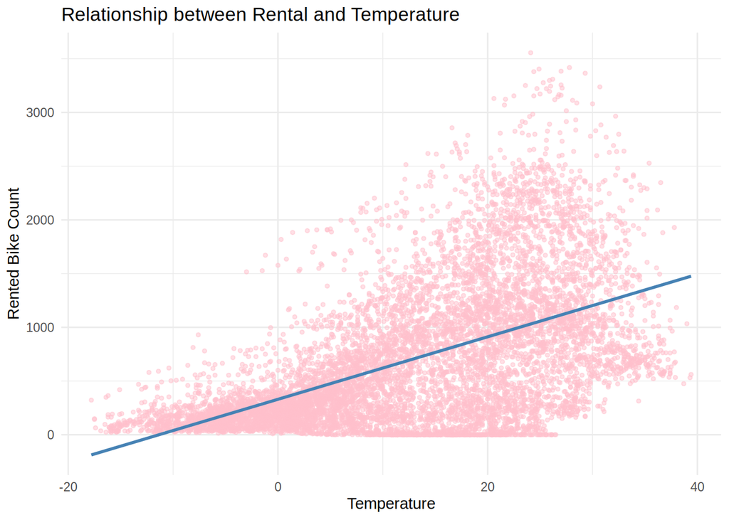

```r
bike_data %>%
  drop_na(Rented.Bike.Count, Temperature.蚓.) %>%
  ggplot(mapping = aes(x = Temperature.蚓., y = Rented.Bike.Count)) +
  geom_point(alpha = 0.5, size = 1, color = "pink") +
  geom_smooth(method = lm, se = FALSE, colour = "steelblue") +
  labs(x = "Temperature",
       y = "Rented Bike Count",
       title = "Relationship between Rental and Temperature") +
  theme_minimal() +
  theme(legend.position = "bottom")
```

```r
Bike_data_temp_lm <- linear_reg() %>%
  set_engine("lm") %>%
  fit(Rented.Bike.Count ~ Temperature.蚓.,
    data = bike_data)

tidy(Bike_data_temp_lm)
```

```
## # A tibble: 2 × 5
##   term            estimate std.error statistic   p.value
##   <chr>              <dbl>     <dbl>     <dbl>     <dbl>
## 1 (Intercept)        330.      8.54       38.6 1.29e-301
## 2 Temperature.蚓.     29.1     0.486      59.8 0
```

```r
glance(Bike_data_temp_lm)
```

```
## # A tibble: 1 × 12
##   r.squared adj.r.squared sigma statistic p.value    df  logLik     AIC     BIC
##       <dbl>         <dbl> <dbl>     <dbl>   <dbl> <dbl>   <dbl>   <dbl>   <dbl>
## 1     0.290         0.290  543.     3578.       0     1 -67600. 135205. 135226.
## # ℹ 3 more variables: deviance <dbl>, df.residual <int>, nobs <int>
```

Regressionline Temperature: Rental is higher between 20-40 Concentrated in low temperature and Spread away in high temperature(It’s not necessary to rent bike in a low temperature, and it depends on other factors in high temperature) Positive correlation

PRECIPITATION

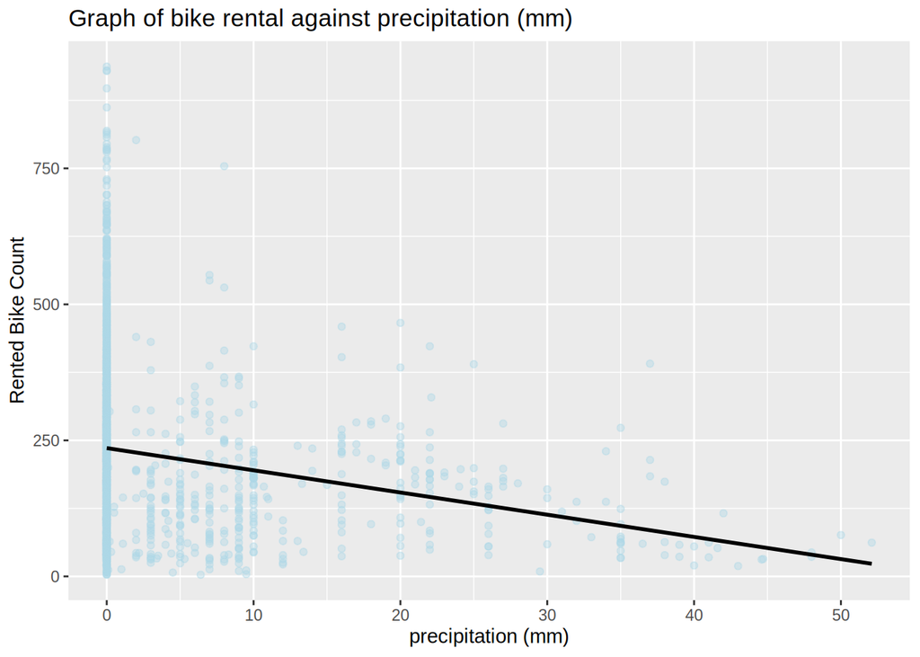

```r
bike_data %>%
  mutate(precipitation.mm = Rainfall.mm.+Snowfall..cm.*10) %>%
  filter(Seasons=="Winter") %>%
  drop_na(Rented.Bike.Count, precipitation.mm) %>%
  ggplot(mapping = aes(x = precipitation.mm, y = Rented.Bike.Count)) +
  geom_point(color = "lightblue",
             alpha = 0.4) +
  geom_smooth( se = FALSE, method = lm, colour = "black") +
  labs(x = "precipitation (mm)",
       y = "Rented Bike Count",
       title = "Graph of bike rental against precipitation (mm)")
```

rainfall no rainfall logistic regression graph with rent on one axis - number of bike rentals …

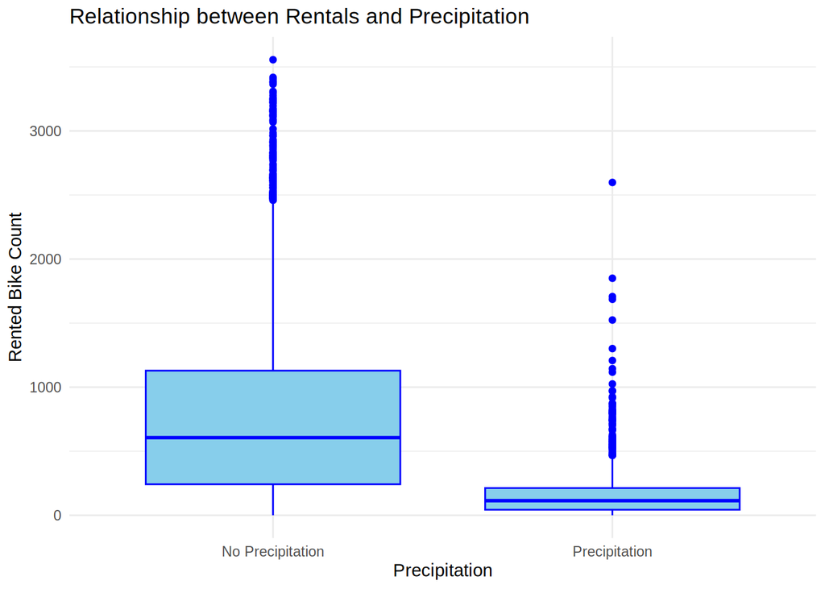

```r
bike_data <- bike_data %>%
  mutate(
    Precipitation = case_when(
      Rainfall.mm. > 0 | Snowfall..cm. > 0 ~ "Precipitation",
      TRUE ~ "No Precipitation"),
    Precipitation = factor(
      Precipitation,
      levels = c("No Precipitation", "Precipitation")))

bike_precipitation_plot <- bike_data %>%
  ggplot(aes(
    x = Precipitation,
    y = Rented.Bike.Count)) +
  geom_boxplot(
    color = "blue",
    fill = "skyblue") +
  labs(
    x = "Precipitation",
    y = "Rented Bike Count",
    title = "Relationship between Rentals and Precipitation") +
  theme_minimal() +
  theme(
    legend.position = "bottom")

bike_precipitation_plot
```

**Exploring Further** Perhaps its exploring the linear relationship between temperature, precipitation and bike rentals

DEW POINT

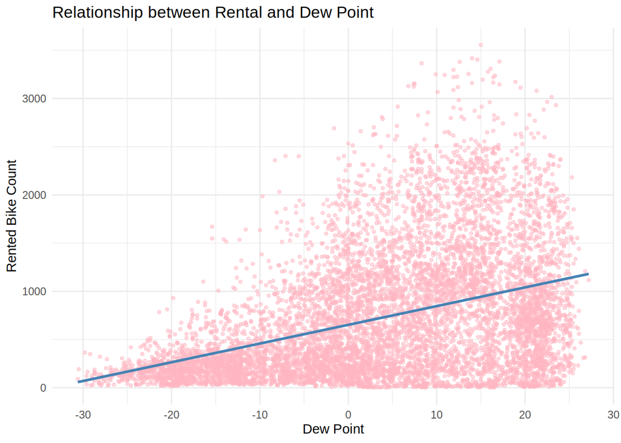

```r
bike_data %>%
  filter(Functioning.Day == "Yes") %>%
  drop_na(Rented.Bike.Count, Dew.point.temperature.蚓.) %>%
  ggplot(mapping = aes(x = Dew.point.temperature.蚓., y = Rented.Bike.Count)) +
  geom_point(color = "#FFB6C1",
             alpha = 0.5,
             size = 1) +
  geom_smooth(method = lm, se = FALSE, colour = "steelblue") +
  labs(x = "Dew Point",
       y = "Rented Bike Count",
       title = "Relationship between Rental and Dew Point") +
   theme_minimal() +
  theme(legend.position = "bottom")
```

```r
Bike_data_dew_lm <- linear_reg() %>%
  set_engine("lm") %>%
  fit(Rented.Bike.Count ~ Dew.point.temperature.蚓.,
    data = bike_data)

tidy(Bike_data_dew_lm)
```

```
## # A tibble: 2 × 5
##   term                      estimate std.error statistic   p.value
##   <chr>                        <dbl>     <dbl>     <dbl>     <dbl>
## 1 (Intercept)                  628.      6.68       94.1 0
## 2 Dew.point.temperature.蚓.     18.8     0.488      38.4 1.33e-298
```

```r
glance(Bike_data_dew_lm)
```

```
## # A tibble: 1 × 12
##   r.squared adj.r.squared sigma statistic   p.value    df  logLik     AIC    BIC
##       <dbl>         <dbl> <dbl>     <dbl>     <dbl> <dbl>   <dbl>   <dbl>  <dbl>
## 1     0.144         0.144  597.     1476. 1.33e-298     1 -68418. 136842. 1.37e5
## # ℹ 3 more variables: deviance <dbl>, df.residual <int>, nobs <int>
```

Actually nothing different, but we will keep the new one. Dew Point: Rental is higher when dew point is higher. They are widely spread when dew point is high (other factors are influencing?) As there are a lot of zero point exit on unfuntioning day, we should drop them. Positive correlation.

**Exploring Further**

WIND SPEED:

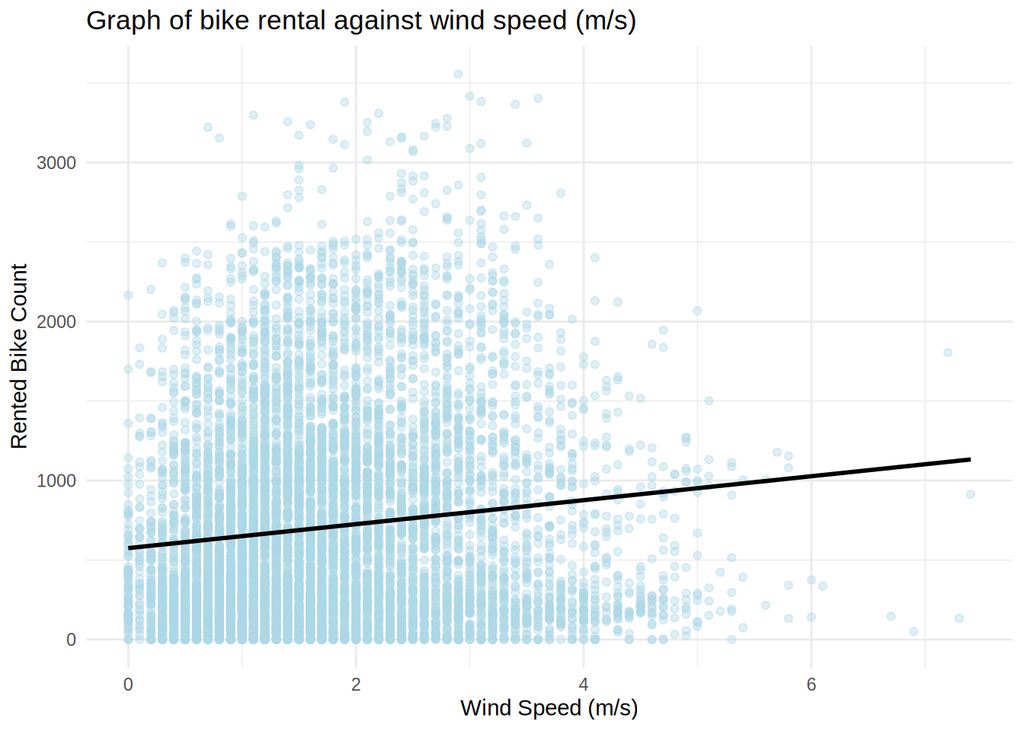

```r
bike_data %>%
  drop_na(Rented.Bike.Count, Wind.speed..m.s.) %>%
  ggplot(mapping = aes(x = Wind.speed..m.s., y = Rented.Bike.Count)) +
  geom_point(color = "lightblue",
             alpha = 0.4) +
  geom_smooth( se = FALSE, method = lm, colour = "black") +
  labs(x = "Wind Speed (m/s)",
       y = "Rented Bike Count",
       title = "Graph of bike rental against wind speed (m/s)") +
  theme_minimal()
```

```r
Bike_data_wind_lm <- linear_reg() %>%
  set_engine("lm") %>%
  fit(Rented.Bike.Count ~ Wind.speed..m.s.,
    data = bike_data)

tidy(Bike_data_wind_lm)
```

```
## # A tibble: 2 × 5
##   term             estimate std.error statistic  p.value
##   <chr>               <dbl>     <dbl>     <dbl>    <dbl>
## 1 (Intercept)         575.      13.3       43.3 0
## 2 Wind.speed..m.s.     75.4      6.60      11.4 5.54e-30
```

```r
glance(Bike_data_wind_lm)
```

```
## # A tibble: 1 × 12
##   r.squared adj.r.squared sigma statistic  p.value    df  logLik     AIC     BIC
##       <dbl>         <dbl> <dbl>     <dbl>    <dbl> <dbl>   <dbl>   <dbl>   <dbl>
## 1    0.0147        0.0146  640.      130. 5.54e-30     1 -69035. 138077. 138098.
## # ℹ 3 more variables: deviance <dbl>, df.residual <int>, nobs <int>
```

NEED TO LOOK AT

“Humidity…”  
“Visibility..10m.” “Solar.Radiation..MJ.m2.” HUMIDITY

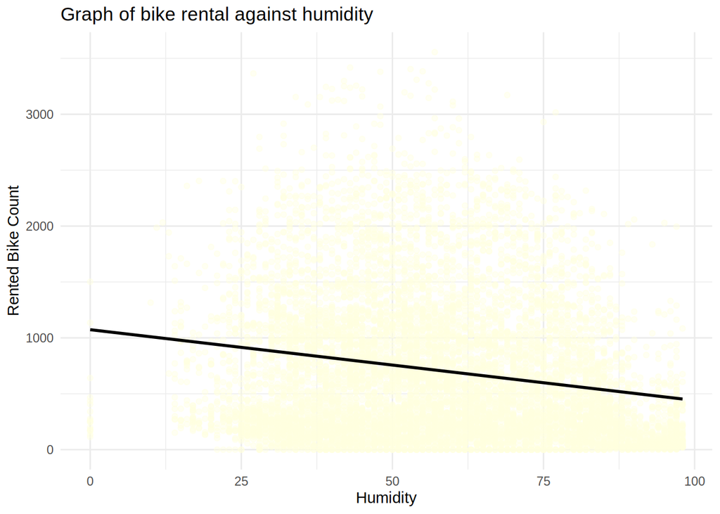

```r
bike_data %>%
  drop_na(Rented.Bike.Count, Humidity...) %>%
  ggplot(mapping = aes(x = Humidity..., y = Rented.Bike.Count)) +
  geom_point(color = "lightyellow",
             alpha = 0.4) +
  geom_smooth( se = FALSE, method = lm, colour = "black") +
  labs(x = "Humidity",
       y = "Rented Bike Count",
       title = "Graph of bike rental against humidity")+
  theme_minimal()
```

```r
Bike_data_hum_lm <- linear_reg() %>%
  set_engine("lm") %>%
  fit(Rented.Bike.Count ~ Humidity...,
    data = bike_data)

tidy(Bike_data_hum_lm)
```

```
## # A tibble: 2 × 5
##   term        estimate std.error statistic  p.value
##   <chr>          <dbl>     <dbl>     <dbl>    <dbl>
## 1 (Intercept)  1073.      20.5        52.5 0
## 2 Humidity...    -6.33     0.332     -19.1 1.48e-79
```

```r
glance(Bike_data_hum_lm)
```

```
## # A tibble: 1 × 12
##   r.squared adj.r.squared sigma statistic  p.value    df  logLik     AIC     BIC
##       <dbl>         <dbl> <dbl>     <dbl>    <dbl> <dbl>   <dbl>   <dbl>   <dbl>
## 1    0.0399        0.0398  632.      364. 1.48e-79     1 -68922. 137849. 137870.
## # ℹ 3 more variables: deviance <dbl>, df.residual <int>, nobs <int>
```

VISIBILITY

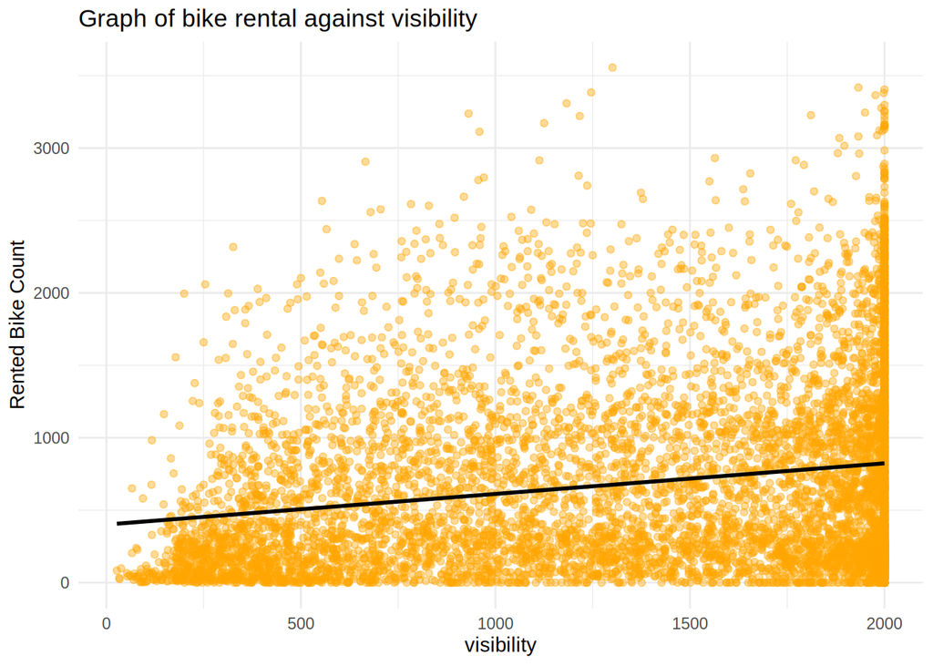

```r
bike_data %>%
  drop_na(Rented.Bike.Count, Visibility..10m.) %>%
  ggplot(mapping = aes(x = Visibility..10m., y = Rented.Bike.Count)) +
  geom_point(color = "orange",
             alpha = 0.4) +
  geom_smooth( se = FALSE, method = lm, colour = "black") +
  labs(x = "visibility",
       y = "Rented Bike Count",
       title = "Graph of bike rental against visibility")+
  theme_minimal()
```

```r
Bike_data_vis_lm <- linear_reg() %>%
  set_engine("lm") %>%
  fit(Rented.Bike.Count ~ Visibility..10m.,
    data = bike_data)

tidy(Bike_data_vis_lm)
```

```
## # A tibble: 2 × 5
##   term             estimate std.error statistic   p.value
##   <chr>               <dbl>     <dbl>     <dbl>     <dbl>
## 1 (Intercept)       401.      17.3         23.1 4.19e-115
## 2 Visibility..10m.    0.211    0.0111      19.0 3.67e- 79
```

```r
glance(Bike_data_vis_lm)
```

```
## # A tibble: 1 × 12
##   r.squared adj.r.squared sigma statistic  p.value    df  logLik     AIC     BIC
##       <dbl>         <dbl> <dbl>     <dbl>    <dbl> <dbl>   <dbl>   <dbl>   <dbl>
## 1    0.0397        0.0396  632.      362. 3.67e-79     1 -68923. 137851. 137872.
## # ℹ 3 more variables: deviance <dbl>, df.residual <int>, nobs <int>
```

SOLAR RADIATION

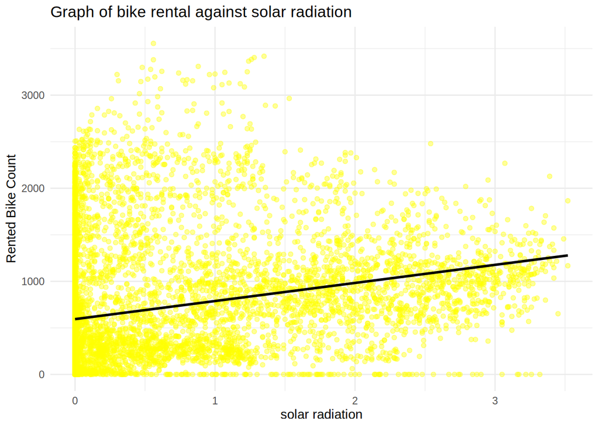

```r
bike_data %>%
  drop_na(Rented.Bike.Count, Solar.Radiation..MJ.m2.) %>%
  ggplot(mapping = aes(x = Solar.Radiation..MJ.m2., y = Rented.Bike.Count)) +
  geom_point(color = "yellow",
             alpha = 0.4) +
  geom_smooth( se = FALSE, method = lm, colour = "black") +
  labs(x = "solar radiation",
       y = "Rented Bike Count",
       title = "Graph of bike rental against solar radiation")+
  theme_minimal()
```

```r
Bike_data_solar_lm <- linear_reg() %>%
  set_engine("lm") %>%
  fit(Rented.Bike.Count ~ Solar.Radiation..MJ.m2.,
    data = bike_data)

tidy(Bike_data_solar_lm)
```

```
## # A tibble: 2 × 5
##   term                    estimate std.error statistic   p.value
##   <chr>                      <dbl>     <dbl>     <dbl>     <dbl>
## 1 (Intercept)                 594.      7.95      74.7 0
## 2 Solar.Radiation..MJ.m2.     194.      7.66      25.4 2.78e-137
```

```r
glance(Bike_data_solar_lm)
```

```
## # A tibble: 1 × 12
##   r.squared adj.r.squared sigma statistic   p.value    df  logLik     AIC    BIC
##       <dbl>         <dbl> <dbl>     <dbl>     <dbl> <dbl>   <dbl>   <dbl>  <dbl>
## 1    0.0686        0.0685  623.      645. 2.78e-137     1 -68789. 137584. 1.38e5
## # ℹ 3 more variables: deviance <dbl>, df.residual <int>, nobs <int>
```

**Exploring Temporal Variables Part 2**

DAYS

[figure not shown]

```r
bike_data %>%
  drop_na(Rented.Bike.Count, Date) %>%
  group_by(Date) %>%
  summarise(
    Mean_Bikes_Day = mean(Rented.Bike.Count),
    .groups = "drop"
  ) %>%
  ggplot(aes(x = Date, y = Mean_Bikes_Day)) +
  geom_col() +
  labs(
    x = "Date",
    y = "Mean Bikes Rented",
    title = "Mean Bike Rentals by Day")
```

**Exploring Further**

WEEKDAYS

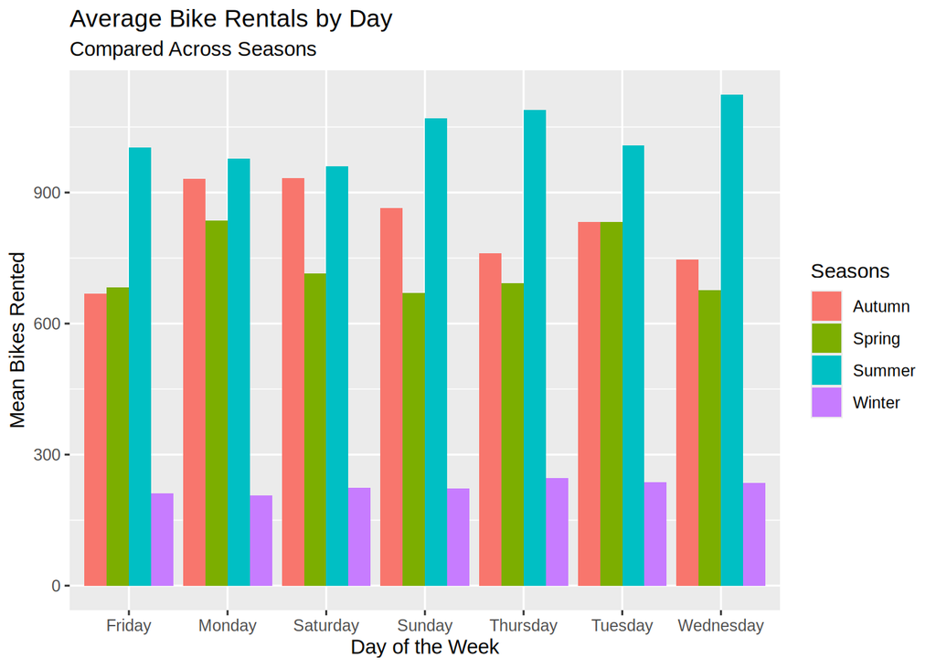

```r
bike_data %>%
  drop_na(Rented.Bike.Count, Date, Seasons) %>%
  mutate(Day = weekdays(as.Date(Date))) %>%
  group_by(Day, Seasons) %>%
  summarise(
    Mean_Bikes_Day = mean(Rented.Bike.Count),
    .groups = "drop"
  ) %>%
  ggplot(aes(x = Day, y = Mean_Bikes_Day, fill = Seasons)) +
  geom_col(position = "dodge") +
  labs(
    x = "Day of the Week",
    y = "Mean Bikes Rented",
    title = "Average Bike Rentals by Day",
    subtitle = "Compared Across Seasons")
```

**Exploring Further**

HOURS

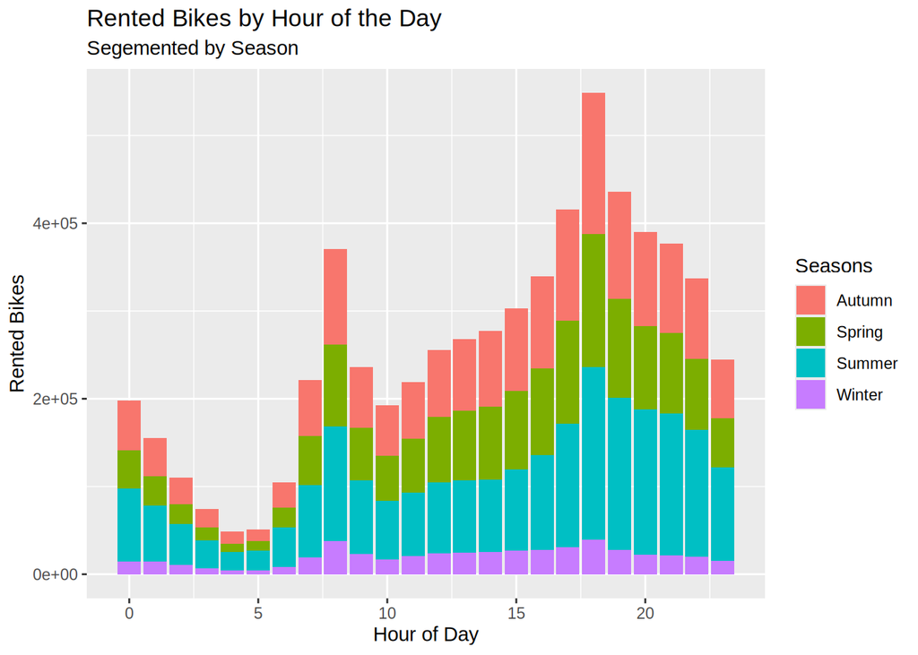

```r
bike_data %>%
  drop_na(Rented.Bike.Count, Hour) %>%
  group_by(Hour, Seasons) %>%
  summarise(Total_Bikes_Hour = sum(Rented.Bike.Count), .groups = "drop") %>%
  ggplot(aes(x= Hour, y= Total_Bikes_Hour, fill = Seasons)) +
  geom_col() +
  labs (
    x= "Hour of Day",
    y= "Rented Bikes",
    subtitle = "Segemented by Season",
    title =  "Rented Bikes by Hour of the Day")
```

**Exploring Further**

MONTHS

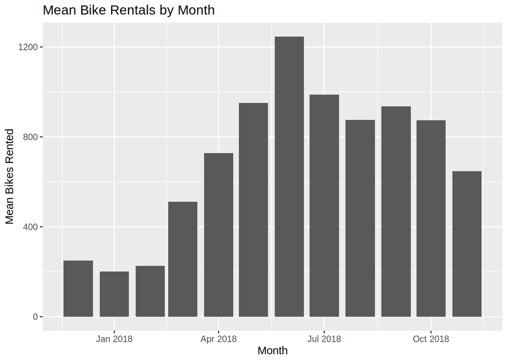

```r
bike_data$Date <- as.Date(bike_data$Date, format = "%d/%m/%Y")

bike_data %>%
  drop_na(Rented.Bike.Count, Date) %>%
  mutate(Month = floor_date(Date, unit = "month")) %>%
  group_by(Month) %>%
  summarise(
    Mean_Bikes_Month = mean(Rented.Bike.Count),
    .groups = "drop"
  ) %>%
  ggplot(aes(x = Month, y = Mean_Bikes_Month)) +
  geom_col() +
  labs(
    x = "Month",
    y = "Mean Bikes Rented",
    title = "Mean Bike Rentals by Month")
```

**Exploring Further**

**Further Explorations**

RAINFALL + dew point + solar + TEMP + RENT Predicting the ROC

```r
bike_data_rent <- bike_data %>%
  select(
    Temperature.蚓.,
    Rainfall.mm.,
    Snowfall..cm.,
    Rented.Bike.Count,
    Solar.Radiation..MJ.m2.,
    Dew.point.temperature.蚓.) %>%
  drop_na()

bike_data_rent <- bike_data_rent %>%
  mutate(
    Precipitation = case_when(
      Rainfall.mm. > 0 | Snowfall..cm. > 0 ~ "Precipitation",
      TRUE ~ "No Precipitation"),
    Precipitation = factor(
      Precipitation,
      levels = c("No Precipitation", "Precipitation")))%>%
  mutate(
    Demand = case_when(
      Rented.Bike.Count > median(Rented.Bike.Count) ~ "HighDemand",
      TRUE ~ "LowDemand"),
    Demand = factor(
      Demand,
      levels = c("LowDemand", "HighDemand")))


set.seed(1234)

Bike_data_rent_split <- initial_split(bike_data_rent)
Bike_data_rent_train <- training(Bike_data_rent_split)
Bike_data_rent_test  <- testing(Bike_data_rent_split)

Bike_data_rent_rec <- recipe(
  Demand ~ Temperature.蚓. + Precipitation + Solar.Radiation..MJ.m2. + Dew.point.temperature.蚓.,
  data = Bike_data_rent_train
)

Bike_data_rent_mod <- logistic_reg() %>%
  set_engine("glm")

Bike_data_rent_wflow <- workflow() %>%
  add_model(Bike_data_rent_mod) %>%
  add_recipe(Bike_data_rent_rec)

Bike_data_rent_fit <- Bike_data_rent_wflow %>%
  fit(data = Bike_data_rent_train)

tidy(Bike_data_rent_fit)
```

```
## # A tibble: 5 × 5
##   term                       estimate std.error statistic   p.value
##   <chr>                         <dbl>     <dbl>     <dbl>     <dbl>
## 1 (Intercept)                  -2.61    0.0967     -27.0  9.97e-161
## 2 Temperature.蚓.               0.236   0.0104      22.7  4.06e-114
## 3 PrecipitationPrecipitation   -2.29    0.170      -13.4  3.85e- 41
## 4 Solar.Radiation..MJ.m2.       0.399   0.0565       7.05 1.73e- 12
## 5 Dew.point.temperature.蚓.    -0.100   0.00833    -12.0  3.36e- 33
```

```r
glance(Bike_data_rent_fit)
```

```
## # A tibble: 1 × 8
##   null.deviance df.null logLik   AIC   BIC deviance df.residual  nobs
##           <dbl>   <int>  <dbl> <dbl> <dbl>    <dbl>       <int> <int>
## 1         9108.    6569 -2849. 5707. 5741.    5697.        6565  6570
```

```r
bike_data_rent_pred <- predict(
  Bike_data_rent_fit,
  Bike_data_rent_test,
  type = "prob"
)

bike_data_rent_pred <- bind_cols(
  Bike_data_rent_test %>% select(Demand),
  bike_data_rent_pred
)

glimpse(bike_data_rent_pred)
```

```
## Rows: 2,190
## Columns: 3
## $ Demand           <fct> LowDemand, LowDemand, LowDemand, LowDemand, LowDemand…
## $ .pred_LowDemand  <dbl> 0.9099789, 0.9046954, 0.9018252, 0.5827611, 0.5118802…
## $ .pred_HighDemand <dbl> 0.09002112, 0.09530456, 0.09817478, 0.41723886, 0.488…
```

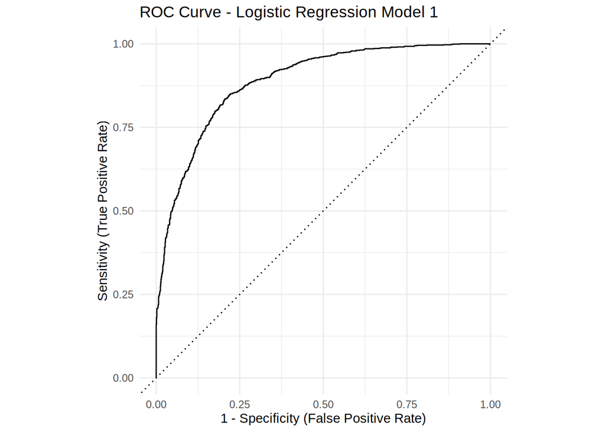

```r
bike_data_rent_roc <- bike_data_rent_pred %>%
  roc_curve(
    truth = Demand,
    .pred_HighDemand,
    event_level = "second"
  )

autoplot(bike_data_rent_roc) +
  labs(
    title = "ROC Curve - Logistic Regression Model 1",
    x = "1 - Specificity (False Positive Rate)",
    y = "Sensitivity (True Positive Rate)"
  ) +
  theme_minimal()
```

```r
bike_data_rent_auc <- bike_data_rent_pred %>%
  roc_auc(
        truth = Demand,
    .pred_HighDemand,
    event_level = "second")
bike_data_rent_auc
```

```
## # A tibble: 1 × 3
##   .metric .estimator .estimate
##   <chr>   <chr>          <dbl>
## 1 roc_auc binary         0.888
```

LINEAT REG TEMP + RAIN

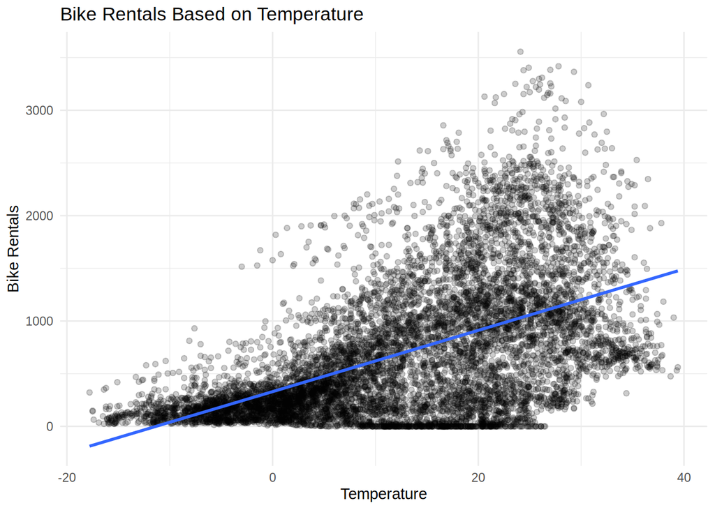

```r
bike_data_rain <- bike_data %>%
  select(
    Temperature.蚓.,
    Rainfall.mm.,
    Snowfall..cm.,
    Rented.Bike.Count) %>%
  drop_na()

bike_data_rain <- bike_data_rain %>%
  mutate(
    Precipitation = case_when(
      Rainfall.mm. > 0 | Snowfall..cm. > 0 ~ "Precipitation",
      TRUE ~ "No Precipitation"),
    Precipitation = factor(
      Precipitation,
      levels = c("No Precipitation", "Precipitation")))

Bike_data_temp_lm <- linear_reg() %>%
  set_engine("lm") %>%
  fit(Rented.Bike.Count ~ Temperature.蚓.,
    data = bike_data_rain)

bike_data_rain %>%
  ggplot(aes(
    x = Temperature.蚓.,
    y = Rented.Bike.Count)) +
  geom_point(alpha = 0.2) +
  geom_smooth(method = "lm", se = FALSE) +
  labs(
    title = "Bike Rentals Based on Temperature",
    x = "Temperature",
    y = "Bike Rentals") +
  theme_minimal()
```

```r
tidy(Bike_data_temp_lm)
```

```
## # A tibble: 2 × 5
##   term            estimate std.error statistic   p.value
##   <chr>              <dbl>     <dbl>     <dbl>     <dbl>
## 1 (Intercept)        330.      8.54       38.6 1.29e-301
## 2 Temperature.蚓.     29.1     0.486      59.8 0
```

```r
glance(Bike_data_temp_lm)
```

```
## # A tibble: 1 × 12
##   r.squared adj.r.squared sigma statistic p.value    df  logLik     AIC     BIC
##       <dbl>         <dbl> <dbl>     <dbl>   <dbl> <dbl>   <dbl>   <dbl>   <dbl>
## 1     0.290         0.290  543.     3578.       0     1 -67600. 135205. 135226.
## # ℹ 3 more variables: deviance <dbl>, df.residual <int>, nobs <int>
```

```r
Bike_data_rain_lm <- linear_reg() %>%
  set_engine("lm") %>%
  fit(Rented.Bike.Count ~ Precipitation,
    data = bike_data_rain)

tidy(Bike_data_rain_lm)
```

```
## # A tibble: 2 × 5
##   term                       estimate std.error statistic   p.value
##   <chr>                         <dbl>     <dbl>     <dbl>     <dbl>
## 1 (Intercept)                    768.      6.99     110.  0
## 2 PrecipitationPrecipitation    -593.     21.3      -27.8 3.49e-163
```

```r
glance(Bike_data_rain_lm)
```

```
## # A tibble: 1 × 12
##   r.squared adj.r.squared sigma statistic   p.value    df  logLik     AIC    BIC
##       <dbl>         <dbl> <dbl>     <dbl>     <dbl> <dbl>   <dbl>   <dbl>  <dbl>
## 1    0.0811        0.0810  618.      773. 3.49e-163     1 -68729. 137465. 1.37e5
## # ℹ 3 more variables: deviance <dbl>, df.residual <int>, nobs <int>
```

```r
Bike_data_combined_lm <- linear_reg() %>%
  set_engine("lm") %>%
  fit(Rented.Bike.Count ~ Precipitation + Temperature.蚓.,
    data = bike_data_rain)

tidy(Bike_data_combined_lm)
```

```
## # A tibble: 3 × 5
##   term                       estimate std.error statistic   p.value
##   <chr>                         <dbl>     <dbl>     <dbl>     <dbl>
## 1 (Intercept)                   398.      8.83       45.1 0
## 2 PrecipitationPrecipitation   -419.     18.5       -22.7 1.06e-110
## 3 Temperature.蚓.                27.3     0.479      56.9 0
```

```r
glance(Bike_data_combined_lm)
```

```
## # A tibble: 1 × 12
##   r.squared adj.r.squared sigma statistic p.value    df  logLik     AIC     BIC
##       <dbl>         <dbl> <dbl>     <dbl>   <dbl> <dbl>   <dbl>   <dbl>   <dbl>
## 1     0.329         0.329  528.     2151.       0     2 -67350. 134707. 134736.
## # ℹ 3 more variables: deviance <dbl>, df.residual <int>, nobs <int>
```

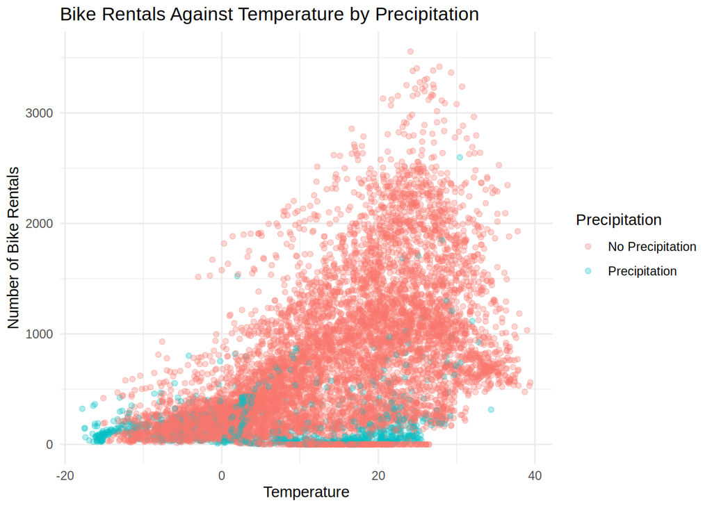

```r
bike_data_rain %>%
  ggplot(aes(
    x = Temperature.蚓.,
    y = Rented.Bike.Count,
    colour = Precipitation)) +
  geom_point(alpha = 0.3) +
  labs(
    title = "Bike Rentals Against Temperature by Precipitation",
    x = "Temperature",
    y = "Number of Bike Rentals",
    colour = "Precipitation") +
  theme_minimal()
```

```r
Bike_data_rain_lm_interaction <- linear_reg() %>%
  set_engine("lm") %>%
  fit(
    Rented.Bike.Count ~ Temperature.蚓. * Precipitation,
    data = bike_data_rain)

tidy(Bike_data_rain_lm_interaction)
```

```
## # A tibble: 4 × 5
##   term                                    estimate std.error statistic   p.value
##   <chr>                                      <dbl>     <dbl>     <dbl>     <dbl>
## 1 (Intercept)                                351.      8.97      39.1  1.25e-308
## 2 Temperature.蚓.                             30.8     0.501     61.4  0
## 3 PrecipitationPrecipitation                -195.     21.3       -9.13 8.20e- 20
## 4 Temperature.蚓.:PrecipitationPrecipitat…    -28.0     1.42     -19.8  4.89e- 85
```

```r
glance(Bike_data_rain_lm_interaction)
```

```
## # A tibble: 1 × 12
##   r.squared adj.r.squared sigma statistic p.value    df  logLik     AIC     BIC
##       <dbl>         <dbl> <dbl>     <dbl>   <dbl> <dbl>   <dbl>   <dbl>   <dbl>
## 1     0.358         0.358  517.     1628.       0     3 -67159. 134327. 134363.
## # ℹ 3 more variables: deviance <dbl>, df.residual <int>, nobs <int>
```

MODE DATA OF TIMES OF DAY 95% CONFIDENCE INTERVAL THROUGH BOOTSRAPPING - MODE HOURS IN THE MORNING AND AFTERNOON FOR BIKE RENTAL

```r
library(infer)
daily_modes <- bike_data %>%
  mutate(
    Time_Period = if_else(Hour < 12, "AM", "PM")
  ) %>%
  group_by(Date, Time_Period) %>%
  slice_max(
    order_by = Rented.Bike.Count,
    n = 1,
    with_ties = FALSE
  ) %>%
  ungroup() %>%
  select(Date, Time_Period, Mode_Hour = Hour)

daily_modes
```

```
## # A tibble: 730 × 3
##    Date       Time_Period Mode_Hour
##    <date>     <chr>           <int>
##  1 2017-12-01 AM                  8
##  2 2017-12-01 PM                 18
##  3 2017-12-02 AM                 11
##  4 2017-12-02 PM                 16
##  5 2017-12-03 AM                  0
##  6 2017-12-03 PM                 15
##  7 2017-12-04 AM                  8
##  8 2017-12-04 PM                 18
##  9 2017-12-05 AM                  8
## 10 2017-12-05 PM                 18
## # ℹ 720 more rows
```

```r
set.seed(1234)

bootstrap_means <- daily_modes %>%
  group_by(Time_Period) %>%
  summarise(
    Sample_Means = list(
      replicate(
        1500,
        mean(
          sample(
            Mode_Hour,
            size = n(),
            replace = TRUE
          )
        )
      )
    ),
    .groups = "drop"
  )

bootstrap_summary <- bootstrap_means %>%
  rowwise() %>%
  mutate(
    Mean_of_Sample_Means = mean(Sample_Means),
    SD_of_Sample_Means = sd(Sample_Means)
  ) %>%
  ungroup()

bootstrap_summary
```

```
## # A tibble: 2 × 4
##   Time_Period Sample_Means  Mean_of_Sample_Means SD_of_Sample_Means
##   <chr>       <list>                       <dbl>              <dbl>
## 1 AM          <dbl [1,500]>                 6.95             0.198
## 2 PM          <dbl [1,500]>                17.4              0.0989
```

```r
bootstrap_summary <- bootstrap_summary %>%
  mutate(
    Lower_CI = Mean_of_Sample_Means -
      1.96 * SD_of_Sample_Means,

    Upper_CI = Mean_of_Sample_Means +
      1.96 * SD_of_Sample_Means
  )

bootstrap_summary
```

```
## # A tibble: 2 × 6
##   Time_Period Sample_Means  Mean_of_Sample_Means SD_of_Sample_Means Lower_CI
##   <chr>       <list>                       <dbl>              <dbl>    <dbl>
## 1 AM          <dbl [1,500]>                 6.95             0.198      6.56
## 2 PM          <dbl [1,500]>                17.4              0.0989    17.2
## # ℹ 1 more variable: Upper_CI <dbl>
```

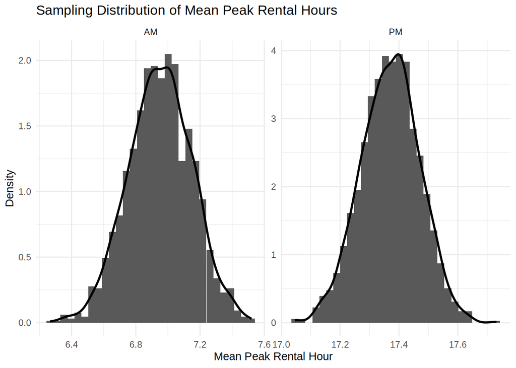

```r
bootstrap_means %>%
  unnest(Sample_Means) %>%
  ggplot(aes(x = Sample_Means)) +
  geom_histogram(
    aes(y = after_stat(density)),
    bins = 30
  ) +
  geom_density(linewidth = 1) +
  facet_wrap(~Time_Period, scales = "free") +
  labs(
    title = "Sampling Distribution of Mean Peak Rental Hours",
    x = "Mean Peak Rental Hour",
    y = "Density"
  ) +
  theme_minimal()
```

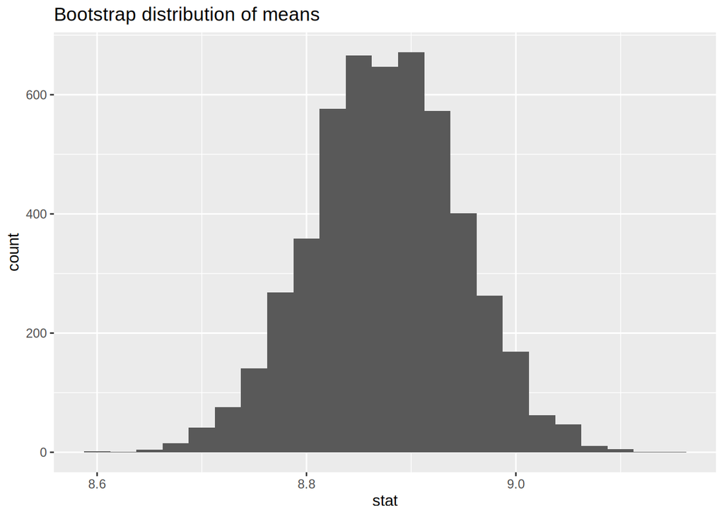

```r
max_hours <- bike_data %>%
  group_by(Date) %>%
  filter( 6<=Hour & Hour<=11) %>%
  filter(Rented.Bike.Count == max(Rented.Bike.Count))

library(infer)
boot_hours <- max_hours %>%
  specify(response=Hour) %>%
  generate(reps=5000, type ="bootstrap") %>%
  calculate(stat="mean")

ggplot(data = boot_hours, mapping = aes(x = stat)) +
  geom_histogram(binwidth = 0.025) +
  labs(title = "Bootstrap distribution of means")
```